# Presenting Regression Analyses in R

Kevin Donovan

March 12, 2021

# Introduction

- We have discussed how to do regression analyses
  - Presenting analyses to communicate results just as important
  - Maximizes the impact of your work
- We will use packages we have discussed before: `ggplot`, `gtsummary`, etc.
  - As well as new ones: `GGally`, `corrplot`, etc.

Tidyverse

# Correlation analyses

- Correlation analyses often presented using boring tables

```
##                   EACSF_V24   ICV_V24   TBV_V24   TCV_V24 LeftAmygdala_V24
## EACSF_V24         1.0000000 0.4967139 0.3776087 0.3682626        0.2796662
## ICV_V24           0.4967139 1.0000000 0.9831674 0.9762236        0.7688862
## TBV_V24           0.3776087 0.9831674 1.0000000 0.9958002        0.7775354
## TCV_V24           0.3682626 0.9762236 0.9958002 1.0000000        0.7758346
## LeftAmygdala_V24  0.2796662 0.7688862 0.7775354 0.7758346        1.0000000
## RightAmygdala_V24 0.2780251 0.7694070 0.7789113 0.7759660        0.8863418
##                   RightAmygdala_V24
## EACSF_V24                 0.2780251
## ICV_V24                   0.7694070
## TBV_V24                   0.7789113
## TCV_V24                   0.7759660
## LeftAmygdala_V24          0.8863418
## RightAmygdala_V24         1.0000000
```

# Correlation analyses

- Instead, let’s use visualizations!

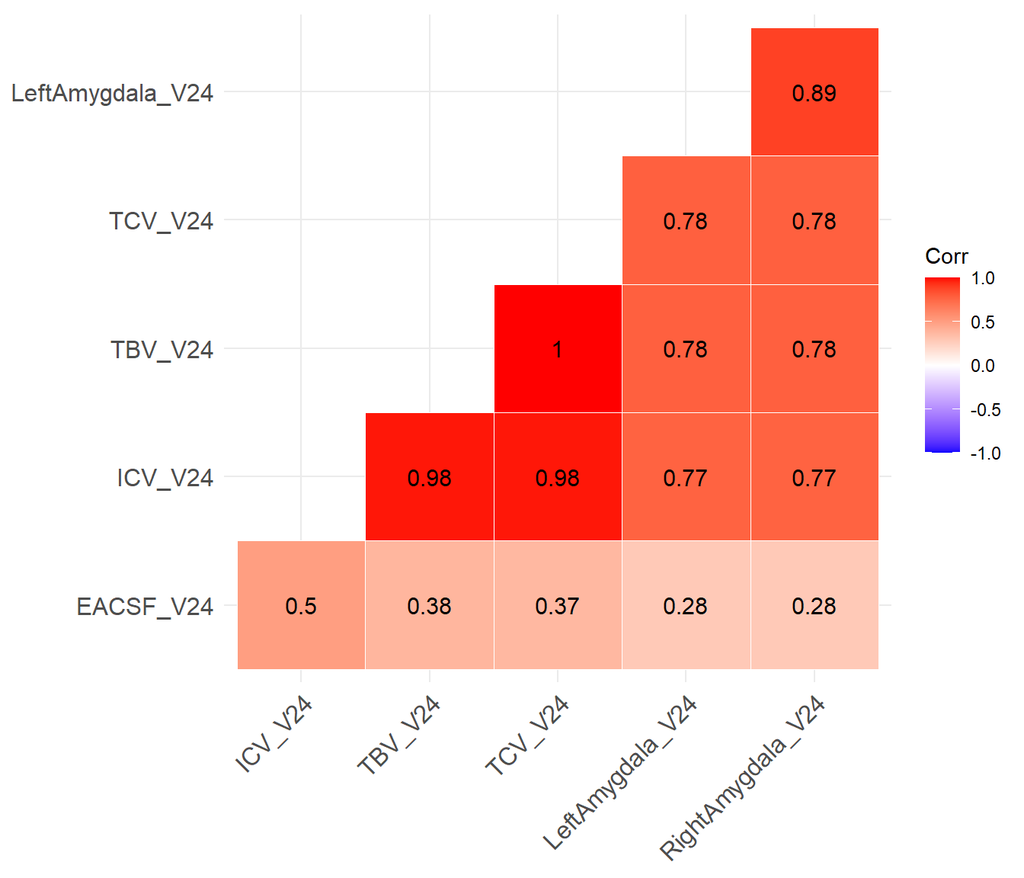

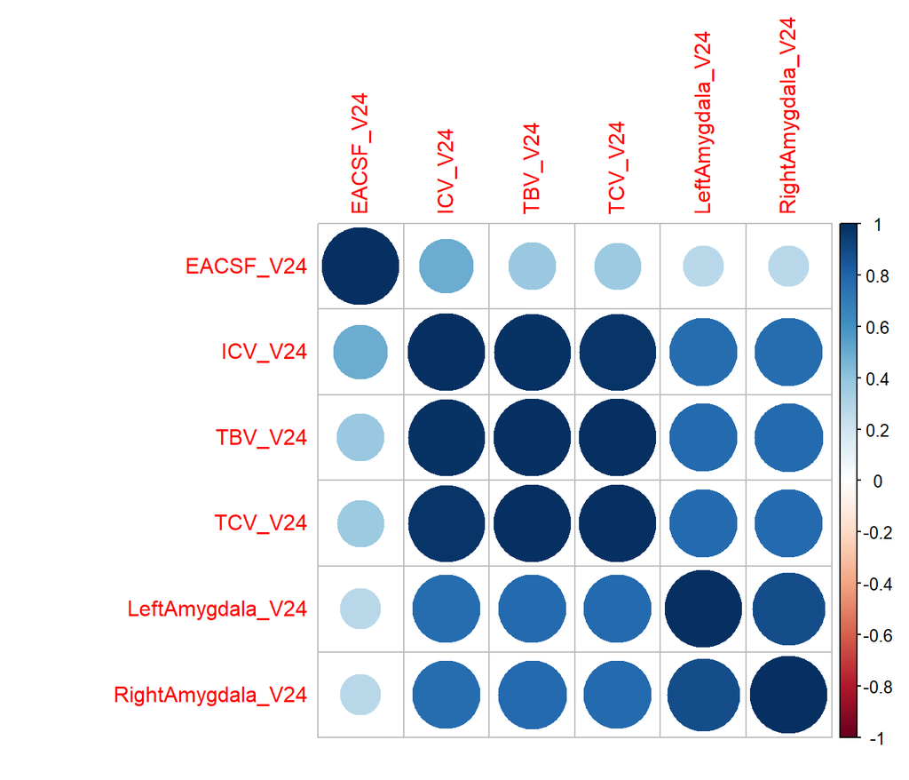

# Correlation analyses

- Can also add in visualizations which look at distributions too

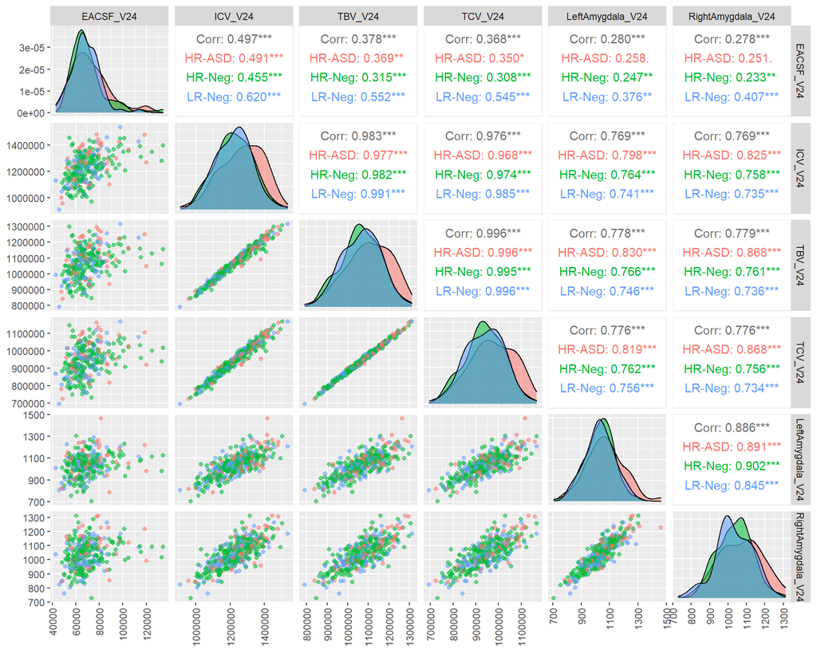

# Summary statistics

- Can create easily formatted summary stats tables **in code**

| Characteristic | N | HR-ASD, N = 781 | HR-Neg, N = 2731 | LR-Neg, N = 1511 | p-value2 |
| --- | --- | --- | --- | --- | --- |
| EACSF_V24 | 292 | 72,487 (16,123) | 70,358 (15,022) | 68,386 (11,828) | 0.3 |
| Missing |  | 30 | 102 | 78 |  |
| ICV_V24 | 359 | 1,270,041 (123,302) | 1,223,180 (108,795) | 1,220,693 (108,481) | 0.014 |
| Missing |  | 23 | 66 | 54 |  |
| TBV_V24 | 359 | 1,104,088 (107,222) | 1,064,502 (95,094) | 1,065,981 (95,287) | 0.024 |
| Missing |  | 23 | 66 | 54 |  |
| TCV_V24 | 359 | 973,873 (99,189) | 938,532 (86,327) | 939,574 (86,906) | 0.027 |
| Missing |  | 23 | 66 | 54 |  |
| LeftAmygdala_V24 | 359 | 1,071 (132) | 1,029 (103) | 1,032 (103) | 0.037 |
| Missing |  | 23 | 66 | 54 |  |
| RightAmygdala_V24 | 359 | 1,072 (115) | 1,036 (97) | 1,033 (99) | 0.044 |
| Missing |  | 23 | 66 | 54 |  |

1Mean (SD)  
2One-way ANOVA

# Regression summaries

- Let’s model 24 month MSEL expressive language scores as Amygdala volume and ASD diagnosis at 24 months
- Common way to look at results: `summary`

```
##
## Call:
## lm(formula = V24_MSEL_EL_ae ~ RiskGroup + RightAmygdala_V24 +
##     RiskGroup * RightAmygdala_V24, data = brain_data)
##
## Residuals:
##     Min      1Q  Median      3Q     Max
## -18.348  -3.159  -0.599   3.324  18.403
##
## Coefficients:
##                                    Estimate Std. Error t value Pr(>|t|)
## (Intercept)                        6.404220   6.900240   0.928   0.3540
## RiskGroupHR-Neg                   15.251840   8.012648   1.903   0.0578 .
## RiskGroupLR-Neg                   22.861074   9.024587   2.533   0.0117 *
## RightAmygdala_V24                  0.011110   0.006403   1.735   0.0836 .
## RiskGroupHR-Neg:RightAmygdala_V24 -0.009279   0.007505  -1.236   0.2172
## RiskGroupLR-Neg:RightAmygdala_V24 -0.015163   0.008514  -1.781   0.0758 .
## ---
## Signif. codes:  0 '***' 0.001 '**' 0.01 '*' 0.05 '.' 0.1 ' ' 1
##
## Residual standard error: 5.425 on 351 degrees of freedom
##   (145 observations deleted due to missingness)
## Multiple R-squared:  0.1478, Adjusted R-squared:  0.1357
## F-statistic: 12.18 on 5 and 351 DF,  p-value: 6.798e-11
```

- Not very eye catching

# Regression summaries: tables

- Let’s start with improved tables containing this same information
- Remade table: `tbl_regression`
  - Can also be used with generalized linear models

| Characteristic | Beta | 95% CI1 | p-value |
| --- | --- | --- | --- |
| RiskGroup |  |  |  |
| HR-ASD | — | — |  |
| HR-Neg | 15.252 | -0.507, 31.011 | 0.058 |
| LR-Neg | 22.861 | 5.112, 40.610 | 0.012 |
| RightAmygdala_V24 | 0.011 | -0.001, 0.024 | 0.084 |
| RiskGroup * RightAmygdala_V24 |  |  |  |
| HR-Neg * RightAmygdala_V24 | -0.009 | -0.024, 0.005 | 0.217 |
| LR-Neg * RightAmygdala_V24 | -0.015 | -0.032, 0.002 | 0.076 |

1CI = Confidence Interval

# Regression summaries: tables

- Can create from scratch using `broom` and `flex_table` packages
  - Can also be used with mixed models using `broom.mixed`

```
##
## Call:
## lm(formula = V24_MSEL_EL_ae ~ RiskGroup + RightAmygdala_V24 +
##     RiskGroup * RightAmygdala_V24, data = brain_data)
##
## Residuals:
##     Min      1Q  Median      3Q     Max
## -18.348  -3.159  -0.599   3.324  18.403
##
## Coefficients:
##                                    Estimate Std. Error t value Pr(>|t|)
## (Intercept)                        6.404220   6.900240   0.928   0.3540
## RiskGroupHR-Neg                   15.251840   8.012648   1.903   0.0578 .
## RiskGroupLR-Neg                   22.861074   9.024587   2.533   0.0117 *
## RightAmygdala_V24                  0.011110   0.006403   1.735   0.0836 .
## RiskGroupHR-Neg:RightAmygdala_V24 -0.009279   0.007505  -1.236   0.2172
## RiskGroupLR-Neg:RightAmygdala_V24 -0.015163   0.008514  -1.781   0.0758 .
## ---
## Signif. codes:  0 '***' 0.001 '**' 0.01 '*' 0.05 '.' 0.1 ' ' 1
##
## Residual standard error: 5.425 on 351 degrees of freedom
##   (145 observations deleted due to missingness)
## Multiple R-squared:  0.1478, Adjusted R-squared:  0.1357
## F-statistic: 12.18 on 5 and 351 DF,  p-value: 6.798e-11
```

```
## # A tibble: 6 x 5
##   term                              estimate std.error statistic p.value
##   <chr>                                <dbl>     <dbl>     <dbl>   <dbl>
## 1 (Intercept)                        6.40      6.90        0.928  0.354
## 2 RiskGroupHR-Neg                   15.3       8.01        1.90   0.0578
## 3 RiskGroupLR-Neg                   22.9       9.02        2.53   0.0117
## 4 RightAmygdala_V24                  0.0111    0.00640     1.74   0.0836
## 5 RiskGroupHR-Neg:RightAmygdala_V24 -0.00928   0.00750    -1.24   0.217
## 6 RiskGroupLR-Neg:RightAmygdala_V24 -0.0152    0.00851    -1.78   0.0758
```

# Regression summaries: visuals

- Tables tell detailed info, but visuals may make more impact
- Ex. group-specific lines of best fit

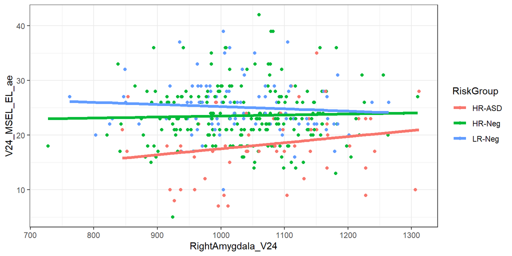

# Regression summaries: visuals

- Least square means (LS means) are a common way of presenting results in interpretable manner
- Can be computed for cross-sectional regression and mixed models
- How are they computed?

$$\begin{align}
&MSEL = \beta_0+\beta_1Amyg+\beta_2HRneg+\beta_3LRneg+\beta_4HRneg*Amyg+\beta_5LRneg*Amyg=\epsilon \\
&LSM(HRneg)=\beta_0+\beta_2+\beta_1x+\beta_4x \text{ where x is fixed value, e.g. mean Amygfala} \\
&LSM(LRneg)=\beta_0+\beta_3+\beta_1x+\beta_5x\\
&LSM(HRASD)=\beta_0+\beta_1x
\end{align}$$

- **Comparing group means** controlling for other covariates in model
- **Note**: not the best metric when interaction terms are included

# Regression summaries: visuals

- LS means can be computed using `lsmeans` function
- Can then plot using `ggplot`

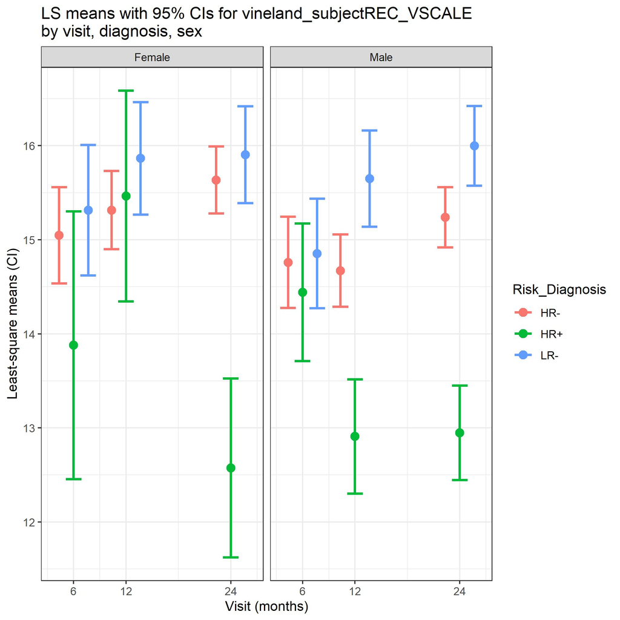

Tidyverse

# Regression summaries: visuals

- Forest plots are one way of visualizing ``beta’’ estimates and confidence intervals
- Very useful when you don’t have interaction terms and have many main effects

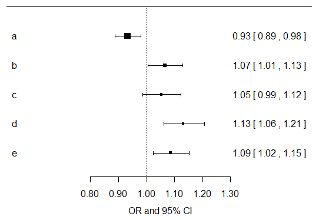